# ONR VR Task Performance

## Overview

Thank you for participating in our study (we hope you had fun!). The purpose of this document is to 1) explain the two tasks that you played in virtual reality (VR); and 2) share your performance for the three testing conditions (Day1 = Rest; Day2 = Exercise; Day3 = No Sleep). Information from your Day 0 is not present since that was considered a practice day.

```
The following document is intended solely for ID # 131
```

————————————————————————————————————————————————————————————————-I

## Go/No-Go

The Go/No-Go task was the first game you played in VR. This task required you to hit certain shapes that were seen often (Go trials) and to avoid hitting shapes that were presented rarely (No-Go trials). This task is a measure of **inhibition ability** since better performance on No-Go trials indicates greater ability to inhibit a habituated response. The graphs below show overall performance for both Go and No-Go trials for all three testing days (left) and the reaction times for correct Go trials (right). Smaller numbers for reaction time indicate quicker speed in hitting the Go trials, which is a good thing.

————————————————————————————————————————————————————————————————-I

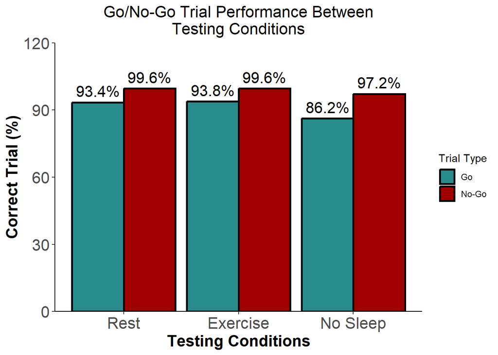

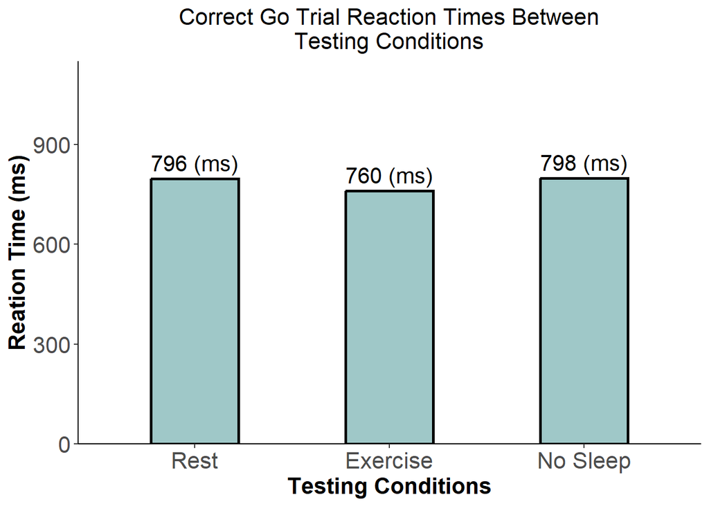

The following bar graph indicates how well you performed compared to the other participants in the study (n=211). These percentiles (not percentages) tell us that for Go trials on your Rest day, you performed better than roughly 59.7% of participants. The same logic applies to the other testing days and trial types.

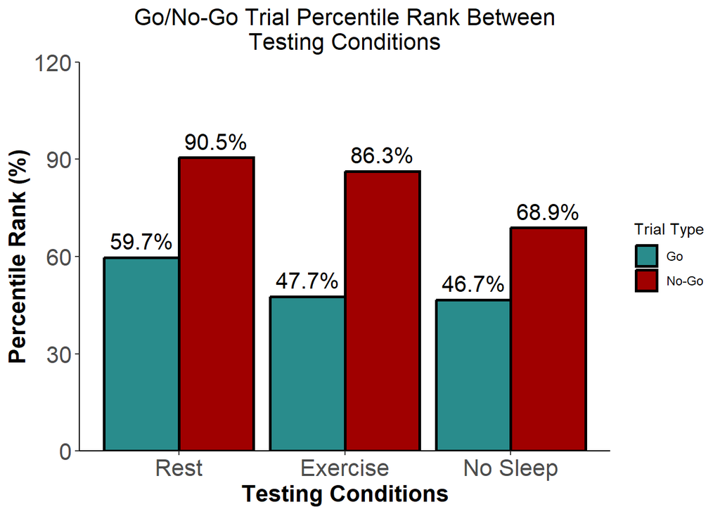

————————————————————————————————————————————————————————————————-I

## NBack

The Nback was the second game you played in VR and is considered to be harder than the Go/No-Go. Our version of this task required you to hit a shape if it matched a shape that you saw two trials back (target). This type of task measures your **working memory ability**. Higher performance on target trials showed you remembered a shape correctly and higher performance on non-target trials indicated a greater ability to not misremember presented stimuli. The graphs below respectively show performance for these trial types for all three testing days (left) and reaction times for correct target trials (right).

————————————————————————————————————————————————————————————————-I

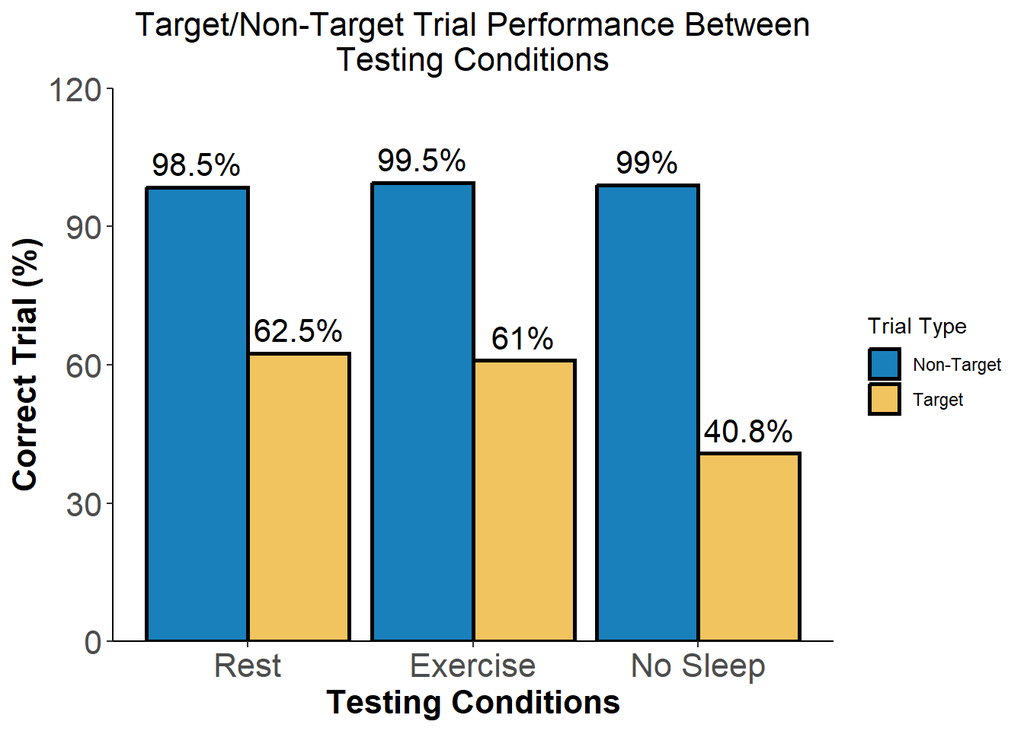

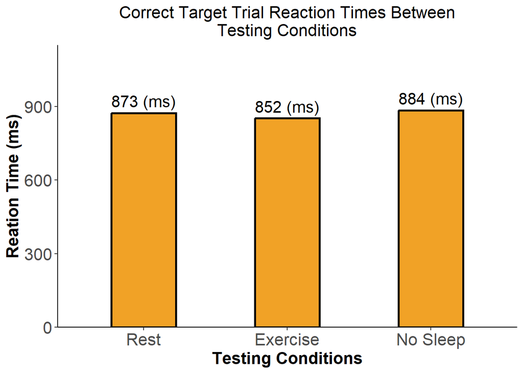

The following bar graph indicates how well you performed compared to the other participants in the study (n=211). These percentiles (not percentages) tell us that for Target trials on your Rest day, you performed better than roughly 76.9% of participants. The same logic applies to the other testing days and trial types.

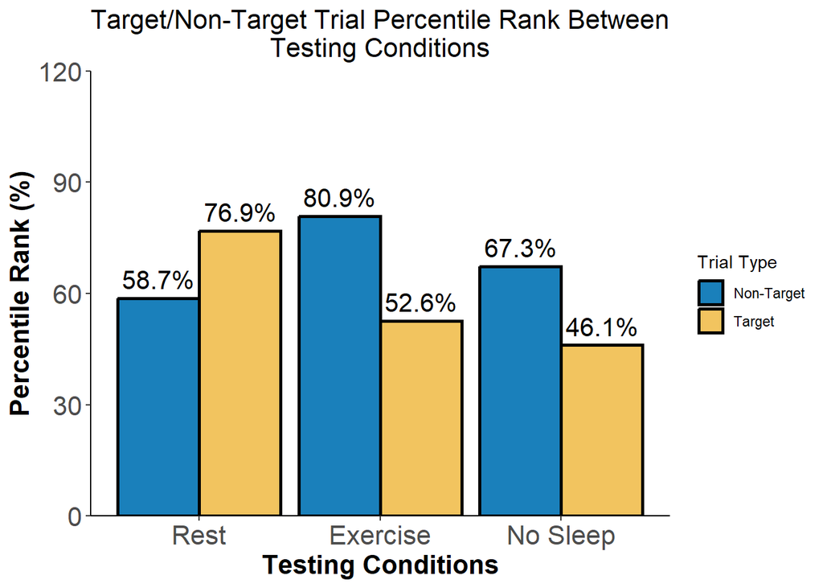

————————————————————————————————————————————————————————————————-I

## ASVAB

The Armed Services Vocational Aptitude Battery (ASVAB) is a standardized test that measures knowledge in science, math, language and other domains. You took a shortened version of this test. You were assessed in the following 9 subtests in this order:

- General Science (GS)
- Arithmetic Reasoning (AR)
- Word Knowledge (WK)
- Paragraph Comprehension (PC)
- Mathematical Knowledge (MK)
- Electronics Information (EI)
- Auto and Shop (ASI)
- Mechanical Comprehension (MC)
- Assembling Objects (AO).

Each subtest asked a different number of questions (Total Questions) and only 5 questions from each subtest were asked to everyone. The remaining questions were randomly chosen from a pool of questions for that respective subtest. Thus, it may be possible that your performance (Correct Questions and Correct Percentage) compared to everyone else (Percentile) may not be as accurate since some people might have been asked harder questions than others.

————————————————————————————————————————————————————————————————-I

For the General Science subtest, you answered 8 questions correctly out of 12 questions, which is an accuracy of 66.7%. Your percentile is 69.1% - meaning that you performed better than 69.1% of participants but worse than 30.9%. The same logic applies to the following subtests.

Table 1: ASVAB performance for each subtest

| ID | Subtest | Correct Questions | Total Questions | Correct Percentage | Percentile |
| --- | --- | --- | --- | --- | --- |
| 131 | General Science | 8 | 12 | 66.7 | 69.1 |
| 131 | Arithmetic Reasoning | 9 | 14 | 64.3 | 64.8 |
| 131 | Word Knowledge | 13 | 15 | 86.7 | 70.3 |
| 131 | Paragraph Comprehension | 13 | 15 | 86.7 | 97.9 |
| 131 | Mathematical Knowledge | 7 | 12 | 58.3 | 51.7 |
| 131 | Electronics Information | 1 | 10 | 10.0 | 3.8 |
| 131 | Auto and Shop | 2 | 12 | 16.7 | 14.8 |
| 131 | Mechanical Comprehension | 8 | 12 | 66.7 | 86.0 |
| 131 | Assembling Objects | 12 | 12 | 100.0 | 99.2 |

————————————————————————————————————————————————————————————————-I